# Gestión de archivos y manipulación de datos en R

6/3/2021

## Directorio de trabajo

Es una ruta de archivo que aloja por defecto todos los archivos en una sesión de R

```r
getwd() # ejecuta la ruta
```

```
## [1] "C:/Users/andre/Documents/GitHub_repositories/clinica_datos"
```

```r
dir() # lista de los archivos alojados en el directorio
```

```
##  [1] "clases"
##  [2] "clinica_datos.Rproj"
##  [3] "ejemplo1.csv"
##  [4] "ejemplo1.txt"
##  [5] "ejemplo1.xlsx"
##  [6] "Examen_final.Rmd"
##  [7] "funciones.R"
##  [8] "functions_r_course.Rmd"
##  [9] "gestion_ArchBasDat_R.html"
## [10] "gestion_ArchBasDat_R.Rmd"
## [11] "ggplot2_hadley_wichkham.R"
## [12] "imagenes"
## [13] "inferencia"
## [14] "instalacionR.html"
## [15] "instalacionR.pdf"
## [16] "instalacionR.Rmd"
## [17] "introduccion_R.html"
## [18] "introduccion_R.R"
## [19] "introduccion_R.Rmd"
## [20] "Matloff_2011_the_art_of_R_programming.R"
## [21] "MetCien_probabilidad_estadistica_diseño.Rmd"
## [22] "moneda_trial.tiff"
## [23] "para_D1.pdf"
## [24] "para_D1.Rmd"
## [25] "R_course_hardvard"
## [26] "R_for_data_science.Rmd"
## [27] "README.md"
## [28] "Zuur_2009_beginners_guite_to_r.R"
```

Pueden modificarlo usando la función `setwd()` y especificando la nueva ruta en una cadena de caracter.

```r
setwd("C:/Users/andre/Documents/Publications")
```

**Buenas prácticas:**

- Evitar rutas de acceso excesivamente largas.
- Usar nombres informativos en las carpetas
- Reducir al máximo el uso de espacios entre palabras. Dos alternativas, *mi_carpeta* o *MiCarpeta* en lugar de *mi carpeta*.
- **NO!** usar caracteres especiales en carpetas o nombres de archivos.

## Proyectos en RStudio

Opción para gestionar múltiples directorios de trabajo usando la interfaz gráfica de RStudio.

[figure not shown]

[figure not shown]

## Ingresar datos a partir de archivos

Pueden importan información desde archivos `.xlsx`, `.csv` y `.txt`. Pero si lo que requieren es cargar información de paquetes estadísticos como SPSS, Stata, SAS, Systat, entre otros, querrán explorar el paquete `foreing`. Acá trataremos los tres primeros.

**Archivos de Excel .xlsx**

```r
library(readxl) # cargar el paquete readxl y usar la función read_excel
read_excel("ejemplo1.xlsx", sheet = 1, col_names = TRUE)
```

```
## # A tibble: 8 x 3
##        a b     c
##    <dbl> <chr> <chr>
## 1 651    f     s
## 2 652    f     s
## 3   8    f     s
## 4  16.9  d     s
## 5  51    d     s
## 6   8.74 d     s
## 7   2    c     s
## 8  65    c     s
```

En el ejemplo anterior solo indicamos el nombre del archivo dado que está alojado en el directorio. Si no lo estuviera…

```r
read_excel("C:/Users/andre/OneDrive/Escritorio/ejemplo1.xlsx",
           sheet = 1, col_names = TRUE)
```

```
## # A tibble: 8 x 3
##       a b     c
##   <dbl> <chr> <chr>
## 1   651 f     s
## 2   652 f     s
## 3     8 f     s
## 4   169 d     s
## 5    51 d     s
## 6   874 d     s
## 7     2 c     s
## 8    65 c     s
```

Usamos la ruta completa en la que se encuentra el archivo.

## Archivos .csv

Para pasar un .xlsx a .csv en Excel: *save as* **>>** *save as type* **>>** *CSV (Comma delimited)*. Se usa la función de R base `read.csv()``

```r
read.csv("ejemplo1.csv", sep = ";", dec = ",", header = TRUE)
```

```
##        a b c
## 1 651.00 f s
## 2 652.00 f s
## 3   8.00 f s
## 4  16.90 d s
## 5  51.00 d s
## 6   8.74 d s
## 7   2.00 c s
## 8  65.00 c s
```

Debe considerar la separación de las columnas —esto depende de la configuración de Excel—, el símbolo que denota los decimales y los encabezados de las columnas.

## Archivos .txt

Para pasar un .xlsx a .txt en Excel: *save as* **>>** *save as type* **>>** *Text (Tab delimited)*. Se usa la función de R base `read.table()`.

```r
read.table("ejemplo1.txt", header = TRUE, sep = "\t", dec = ",")
```

```
##        a b c
## 1 651.00 f s
## 2 652.00 f s
## 3   8.00 f s
## 4  16.90 d s
## 5  51.00 d s
## 6   8.74 d s
## 7   2.00 c s
## 8  65.00 c s
```

Recuerde que para guardar la información en el espacio de trabajo (*Global Environment*) debe asignarla a un nombre (i.e., `nombre <- read.table("ejemplo1.txt"...)`).

## ahora que tiene los datos en R…

**- Explorarlos:**

Tipo de variables

NAs, NaN, NULL

**- Organizarlos**

Formato largo

Formato ancho

Usaremos una base de datos morfológicos y fisiológicos de tres especies de pingüinos del Ártico.

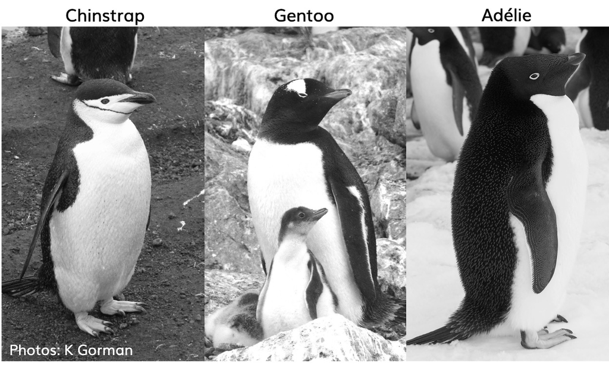

Instale

```r
install.packages("palmerpenguins")
```

cargue el paquete y…

```r
library(palmerpenguins)

str(penguins)
```

```
## tibble [344 x 8] (S3: tbl_df/tbl/data.frame)
##  $ species          : Factor w/ 3 levels "Adelie","Chinstrap",..: 1 1 1 1 1 1 1 1 1 1 ...
##  $ island           : Factor w/ 3 levels "Biscoe","Dream",..: 3 3 3 3 3 3 3 3 3 3 ...
##  $ bill_length_mm   : num [1:344] 39.1 39.5 40.3 NA 36.7 39.3 38.9 39.2 34.1 42 ...
##  $ bill_depth_mm    : num [1:344] 18.7 17.4 18 NA 19.3 20.6 17.8 19.6 18.1 20.2 ...
##  $ flipper_length_mm: int [1:344] 181 186 195 NA 193 190 181 195 193 190 ...
##  $ body_mass_g      : int [1:344] 3750 3800 3250 NA 3450 3650 3625 4675 3475 4250 ...
##  $ sex              : Factor w/ 2 levels "female","male": 2 1 1 NA 1 2 1 2 NA NA ...
##  $ year             : int [1:344] 2007 2007 2007 2007 2007 2007 2007 2007 2007 2007 ...
```

## Clases de variables

Variables de tipo factor o categóricas.

```r
class(penguins$species)
```

```
## [1] "factor"
```

```r
levels(penguins$species)
```

```
## [1] "Adelie"    "Chinstrap" "Gentoo"
```

```r
summary(penguins$species)
```

```
##    Adelie Chinstrap    Gentoo
##       152        68       124
```

Numéricas, hay dos tipos.

```r
# integer: números enteros
class(penguins$body_mass_g); summary(penguins$body_mass_g)
```

```
## [1] "integer"
```

```
##    Min. 1st Qu.  Median    Mean 3rd Qu.    Max.    NA's
##    2700    3550    4050    4202    4750    6300       2
```

```r
# numeric: números reales
class(penguins$bill_length_mm); summary(penguins$bill_length_mm)
```

```
## [1] "numeric"
```

```
##    Min. 1st Qu.  Median    Mean 3rd Qu.    Max.    NA's
##   32.10   39.23   44.45   43.92   48.50   59.60       2
```

Caracter

```r
class(penguins_raw$Region)
```

```
## [1] "character"
```

```r
summary(penguins_raw$Region)
```

```
##    Length     Class      Mode
##       344 character character
```

A diferencia de los factores las cadenas de caracter no tienen niveles o agrupamientos. Más bien, consisten en secuencias heterogáneas de símbolos cuya manipulación comprende un tema completo en programación computacional, y no serán tratada en este curso.

## NA’s

Los `NA` (not available) son un tipo especial de valor que en R denota los datos faltantes, datos cuyo valor es desconocido. Tienden a ser problemáticos en el momento de computar cálculos, así que R ofrece varías formas de lidiar con ellos.

```r
table(is.na(penguins)) # identificar el número de NAs
```

```
##
## FALSE  TRUE
##  2733    19
```

```r
table(is.na(na.omit(penguins))) # remover NAs
```

```
##
## FALSE
##  2664
```

La anterior es una práctica que se debe realizar con precaución. Dependiendo del análisis, es preferible evaluar el caso de variables particulares y usar, por ejemplo:

```r
subset(penguins, !is.na(penguins$bill_length_mm))
```

O, en funciones como `mean()` el argumento `na.rm=` controla que el cálculo se realice excluyendo, o no, los datos faltantes

```r
mean(penguins$bill_length_mm)
```

```
## [1] NA
```

```r
mean(penguins$bill_length_mm, na.rm = T)
```

```
## [1] 43.92193
```

## Otros valores especiales

**`NaN`** (not a number). Es retornado cuando el computo produce un valor que no es numérico.

**`NULL`**. Es retornado cuando un cmputo produce un valor indeterminado o inexistente.

**`Inf` - `-Inf`**. Valores muy grandes o el cociente de una división por cero

`NA`, `NaN`, `NULL` e `Inf` son palabras reservadas en R. Es decir, ningún objeto puede adquirir su nombre.

```r
NA <- "a"
```

```
## Error in NA <- "a": invalid (do_set) left-hand side to assignment
```

## Organizando los datos

Función `rbind()`

```r
(new_peng <- rbind(penguins[penguins$species  == "Adelie", ][1:5, c(1, 3)],
                  penguins[penguins$species  == "Chinstrap", ][1:5, c(1, 3)],
                  penguins[penguins$species  == "Gentoo", ][1:5, c(1, 3)]))
```

```
## # A tibble: 15 x 2
##    species   bill_length_mm
##    <fct>              <dbl>
##  1 Adelie              39.1
##  2 Adelie              39.5
##  3 Adelie              40.3
##  4 Adelie              NA
##  5 Adelie              36.7
##  6 Chinstrap           46.5
##  7 Chinstrap           50
##  8 Chinstrap           51.3
##  9 Chinstrap           45.4
## 10 Chinstrap           52.7
## 11 Gentoo              46.1
## 12 Gentoo              50
## 13 Gentoo              48.7
## 14 Gentoo              50
## 15 Gentoo              47.6
```

Función `cbind()`

```r
cbind(penguins[1:7, 1:2], penguins[1:7, 3:5])
```

```
##   species    island bill_length_mm bill_depth_mm flipper_length_mm
## 1  Adelie Torgersen           39.1          18.7               181
## 2  Adelie Torgersen           39.5          17.4               186
## 3  Adelie Torgersen           40.3          18.0               195
## 4  Adelie Torgersen             NA            NA                NA
## 5  Adelie Torgersen           36.7          19.3               193
## 6  Adelie Torgersen           39.3          20.6               190
## 7  Adelie Torgersen           38.9          17.8               181
```

Función `merge()`

```r
v <- sample(1:nrow(penguins), size = 10)
penguins$id <- as.factor(1:nrow(penguins))

merge(penguins[v, c(1:3, length(penguins))],
      penguins[v, c(1, 2, 4, length(penguins))],
      by = c("species", "island", "id"))
```

```
##      species island  id bill_length_mm bill_depth_mm
## 1     Adelie Biscoe 110           43.2          19.0
## 2     Adelie Biscoe 114           42.2          19.5
## 3     Adelie  Dream  44           44.1          19.7
## 4     Adelie  Dream  46           39.6          18.8
## 5  Chinstrap  Dream 293           50.3          20.0
## 6  Chinstrap  Dream 314           52.0          20.7
## 7  Chinstrap  Dream 340           55.8          19.8
## 8     Gentoo Biscoe 224           46.4          15.6
## 9     Gentoo Biscoe 233           49.1          14.5
## 10    Gentoo Biscoe 272             NA            NA
```

**Formato ancho**

```r
(peng_unst <- unstack(new_peng, bill_length_mm ~ species))
```

```
##   Adelie Chinstrap Gentoo
## 1   39.1      46.5   46.1
## 2   39.5      50.0   50.0
## 3   40.3      51.3   48.7
## 4     NA      45.4   50.0
## 5   36.7      52.7   47.6
```

**Formato largo**

[output not shown]

## Manejo de variables en un DF y operaciones agrupadas

paquete `dplyr` y funciones base.